# 6_3_ResidualsAnalysis

# Portmanteau tests for autocorrelation

Checking if each autocorrelation coefficient is within the negligible autocorrelation limits is equivalent to carrying out multiple hypothesis tests, each one with a small probability of giving a false positive. When performing multiple tests, it is likely that at least one will give a false positive.

A possible solution is to test whether the first $l$ autocorreltaion coefficients differ much from the expected outcome for a white noise process. Carrying a test on multiple ACFs is sometimes called a **portmanteau test**, from the french word describing a rack carrying several items of clothing.

There are different possible statistics for Portmanteau tests:

**Box-Pierce Statistic**:

$$\begin{align*}
Q = T \sum_{k=1}^\ell r_k^2,
\end{align*}$$

- $l$ is the maximum lag being considered
- $T$ is the number of observations
- $r_k$ is the k-th autocorrelation coefficient

**Ljung-Box Statistic**

$$\begin{align*}
Q^* = T(T+2) \sum_{k=1}^\ell (T-k)^{-1}r_k^2.
\end{align*}$$

- $l$ is the maximum lag being considered
- $T$ is the number of observations
- $r_k$ is the k-th autocorrelation coefficient

**Main idea behind both tests:**

Instead of evaluating the magnitude of each autocorrelation coefficient, we seek to generate a metric of the overall ammount of autocorrelation of the series. Both the **Box-Pierce and Ljung-Box statistic grow as the amount of autocorrelation in the series grows**. This is because the terms within the sum are proportional to $r_k^2$, achieving two things:

1. All the terms of the sum are greater than 0. The greater the autocorrelation of the different lags, the greater the statistic.
2. Very small autocorrelations become much smaller when squaring them, while medium-large autocorrelations remain relevant in the sum when squaring them. In fact, all autocorrelations become smaller when squaring them because they are $\leq 1$. But the smaller the autocorrelation, the more its initial module is reduced when squaring it. This ensures that very small auto-correlation coefficients do not substantially contribute to the growth of the statistic while medium-large autcorrelation coefficients remain relevant within the sum of the statistic.

The examples below might seem obvious but are worth giving some thought (this idea of squaring is prevalent in the logic behind many statistics and formulas):

- $0.9 * 0.9 = 0.81$ : reduction of 10% of the initial module ($1 - 0.9 = 0.1$)
- $0.7 * 0.7 = 0.49$ : redoction of 30% of the initial module ($1 - 0.7 = 0.3$)
- $0.5 * 0.5 = 0.25$ : reduction of 50% of the initial module ($1 - 0.5 = 0.5$)
- $0.25 * 0.25 = 0.0625$ : reduction of 75% of the initial module ($1-0.25 = 0.25$)
- $0.1 * 0.1 = 0.01$ : reduction of 90% of the initial module ($1 - 0.1 = 0.9$)

**So, summarizing**:

- If each $r_k$ is close to 0 (small autocorrelation), then $Q$ (or $Q*$) will be small.
- If some $r_k$ values are large (positive or negative), then $Q$ (or $Q*$) will be large.

**Suggested values for** $l$:

$l$ (the number of terms in the sum) is something we need to choose. The following recommendations are to be followed

- $l = 10$ for non-seasonal data
- $l = 2m$ for seasonal data, where $m$ is the period of seasonality
- **Caution**:
  - The test is not good if $T/l < 5$. If the suggested values are greater than this threshold, use $l = T/5$.

**Distribution of the statistic**:

- $H_0: r_{ks}\;come\;from\;white\;noise$.
  - In this case $Q$ and $Q*$ would follow a $\chi^2$ distribution with $(l-K)$ degrees of freedom, where $K$ is the number of parameters in the model.
    - If we are calculating the autocorrelation coefficients from raw data and not the autocorrelation of the residuals of a certain model, set $K=0$ for the test.
- $H_1: r_{ks}\;do\;not\;come\;from\;white\;noise$

**Interpretation of the test**:

The test is a right-tailed test. Under $H_0$ (residuals are non-correlated), the value of the statistic should be small and we should remain in the “fail to reject” region. If the statistic resulting from our series is too high, we enter the rejection region. Those values of the statistic have very low probability of occurrence if $H_0$ is true. Thus, we would reject if the the statistic is big enough (p-value is sufficiently small).

As usual, we set a confidence level $\alpha$ to maintain type I error under control. We then compute the statistic and its associated p-value. If its p-value is smaller than alpha, we reject $H_0$. Otherwise we fail to reject $H_0$.

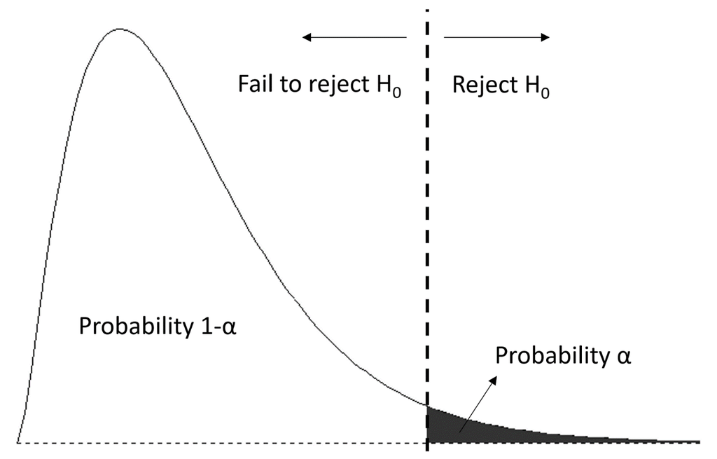

Right tailed test with Chi-squared distribution

## How to determine K, number of parameters of the model

This can be done with the function `tidy()` applied to the fitted model. However, in this particular case, because `decomposition_model()` uses a combination of models, it is necessary to assess the number of parameters of each individual model and then sum them. If we apply `tidy()` to the model fitted using `decomposition_model()` we get the following error pointing us to this fact:

```r
tidy(fit_dcmp)
```

```
Error in `mutate()`:
! Problem while computing `..1 = dplyr::across(all_of(mbl_vars),
  function(x) lapply(x, tidy, ...))`.
Caused by error in `across()`:
! Problem while computing column `decomp`.
Caused by error in `UseMethod()`:
! no applicable method for 'tidy' applied to an object of class "c('decomposition_model', 'model_combination')"
```

So we now proceed to see how many parameters each of the individual models has:

### Number of parameters of the drift model:

```r
dcmp <- retail_series %>%
        model(stl = STL(log(Turnover))) %>%
        components()

season_adjust <- dcmp %>% select(season_adjust)

fit_drift <- season_adjust %>%
             model(Drift = RW(season_adjust ~ drift()))

tidy(fit_drift)
```

```
# A tibble: 1 × 6
  .model term  estimate std.error statistic p.value
  <chr>  <chr>    <dbl>     <dbl>     <dbl>   <dbl>
1 Drift  b      0.00441   0.00318      1.39   0.166
```

```r
# We see that only one parameter is involved in fitting the drift model.
```

### Number of parameters of the seasonal naive model

```r
seasonal <- select(dcmp, season_year)

fit_snaive <- seasonal %>% model(SNaive = SNAIVE(season_year ~ lag("year")))

tidy(fit_snaive)
```

```
# A tibble: 0 × 6
# … with 6 variables: .model <chr>, term <chr>, estimate <dbl>,
#   std.error <dbl>, statistic <dbl>, p.value <dbl>
```

```r
# We see that no parameters are involved in fitting the seasonal naive model (as expected)
```

### Number of parameters of `decomposition_model()`:

In this case we are choosing to:

- Predict the seasonally adjusted component using a drift model (1 parameter)
- Predict the seasonal component using a seasonal naive model (0 parameters)

So the total number of parameters of `decomposition_model()` is 1 + 0 = 1.

We will therefore set $K=1$ in the formula for the degrees of freedom of the Box-Pierce and Ljung-Box tests: $l-K$. Remember that it is necessary to know the degrees of freedom

## Obtaining the Box-Pierce and Ljung-Box statistics:

we will use the functions `augment()` to obtain the residuals and then `features()` from the `fabletools` library applied to the innovation residuals.

In the following code `lag` = $l$ and `dof` = $K$.

**IMPORTANT WARNING**: the Box-Pierce and Ljung-Box statistics will follow a $\chi^2$ distribution with $l-K$ degrees of freedom if $H_0$ is true, but in the code below `dof` refers to the numbers of degrees of freedom constrained by the model (that is, the number $K$ of parameters in the model). The way it is coding is confusing, so **please beware of this difference when coding**.

```r
fit_dcmp %>% augment() %>% features(.innov, box_pierce, lag = 24, dof = 1)
```

```
# A tibble: 1 × 5
  State              Industry                            .model bp_stat bp_pva…¹
  <chr>              <chr>                               <chr>    <dbl>    <dbl>
1 Northern Territory Clothing, footwear and personal ac… decomp    109. 3.12e-13
# … with abbreviated variable name ¹bp_pvalue
```

```r
fit_dcmp %>% augment() %>% features(.innov, ljung_box, lag = 24, dof = 1)
```

```
# A tibble: 1 × 5
  State              Industry                            .model lb_stat lb_pva…¹
  <chr>              <chr>                               <chr>    <dbl>    <dbl>
1 Northern Territory Clothing, footwear and personal ac… decomp    113. 7.44e-14
# … with abbreviated variable name ¹lb_pvalue
```

In both cases the p-value is much smaller than 0.05 and even than 0.01, so we can reject $H_0$ with a 99% confidence level. In other words, the residuals do not come from a white noise series and are therefore correlated.

# Exercise 2

1. Appply a naive method to the Australian Exports series from the dataset `global`

```r
aus_exports <- filter(global_economy, Country == "Australia")
```

```r
# Define and estimate a model
fit <- aus_exports %>% model(Nv = NAIVE(Exports))

fit
```

```
# A mable: 1 x 2
# Key:     Country [1]
  Country        Nv
  <fct>     <model>
1 Australia <NAIVE>
```

2. Extract the fitted values and the residuals

```r
model_vals <- fit %>% augment()
model_vals
```

```
# A tsibble: 58 x 7 [1Y]
# Key:       Country, .model [1]
   Country   .model  Year Exports .fitted  .resid  .innov
   <fct>     <chr>  <dbl>   <dbl>   <dbl>   <dbl>   <dbl>
 1 Australia Nv      1960    13.0    NA   NA      NA
 2 Australia Nv      1961    12.4    13.0 -0.591  -0.591
 3 Australia Nv      1962    13.9    12.4  1.54    1.54
 4 Australia Nv      1963    13.0    13.9 -0.937  -0.937
 5 Australia Nv      1964    14.9    13.0  1.93    1.93
 6 Australia Nv      1965    13.2    14.9 -1.72   -1.72
 7 Australia Nv      1966    12.9    13.2 -0.288  -0.288
 8 Australia Nv      1967    12.9    12.9 -0.0487 -0.0487
 9 Australia Nv      1968    12.3    12.9 -0.586  -0.586
10 Australia Nv      1969    12.0    12.3 -0.343  -0.343
# … with 48 more rows
```

3. Depict the fitted values

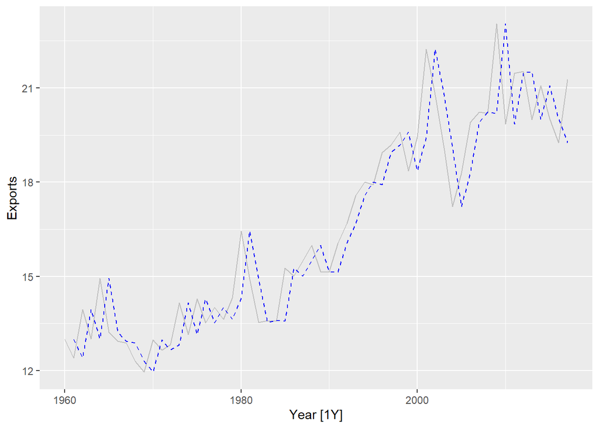

```r
model_vals %>%
  filter(.model == "Nv") %>%
  autoplot(Exports, colour = "gray") +
  geom_line(aes(y=.fitted), colour = "blue", linetype = "dashed")
```

4. Perform the analysis of the residuals. Be as clear an succing as possible:

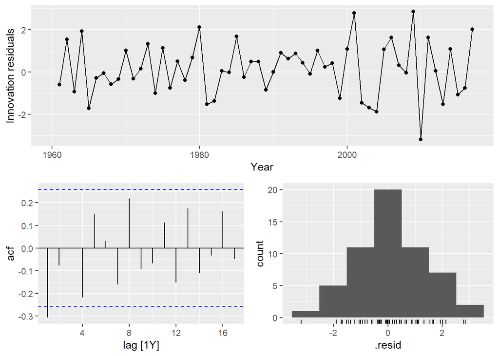

```r
fit %>%
  select(Nv) %>%
  gg_tsresiduals()
```

```r
# Compute the mean of the residuals
model_vals %>% as_tibble() %>%
  filter(.model == "Nv") %>%
  summarise(mean = mean(.innov, na.rm = TRUE))
```

```
# A tibble: 1 × 1
   mean
  <dbl>
1 0.145
```

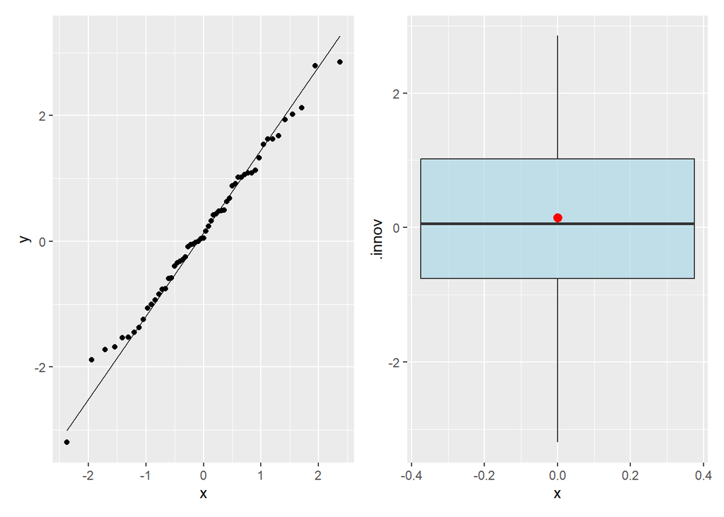

```r
# In this case there is only one model, so this filtering is not really necessary.
nv_vals <- filter(model_vals, .model=="Nv")

# Generate qq_plot
p1 <- ggplot(nv_vals, aes(sample = .innov)) +
        stat_qq() +
        stat_qq_line()

# # Generate box-plot
p2 <- ggplot(data = nv_vals, aes(y = .innov)) +
      geom_boxplot(fill="light blue", alpha = 0.7) +
      stat_summary(aes(x=0), fun="mean", colour= "red") # Include the mean

# Place one graph next to the other (library patchwork)
p1 + p2
```

```r
# Except for the first lag, the rest of the autocorrelation coefficients are
# within the boundaries of negligible autocorrelation. Also the first lag does not
# exceed that boundary by much
#
# The series might therefore still be white noise (5% of the ACF of white noise
# are expected to randomly exceed this threshold due to Type I error).
#
# TO gather further evidence, a Box-Pierce or Ljung test could be carried
# out (not requested in this session).
#
#
# The mean of the residuals differs from 0, which means that forecasts generated
# with this model will be somewhat biased. + More observations appear to be
# above 0, indicating that the model does not capture the trend.
#
# The mean of the residuals differs from 0, which means that forecasts generated
# with this model will be somewhat biased. + More observations appear to be
# above 0, indicating that the model does not capture the trend.
#
# The histogram (symmetric and with balanced tails), QQ-plot (quantiles
# follow the normal cummulative distribution) and Box-Plot (mean close to median
# and symmetry) all seem to indicate that the normality assumption is fair.
```

5. What if we wanted to fit the model to more than one country of the dataset `global economy`?

```r
aus_exports <- filter(global_economy, Country %in% c("Australia", "Spain", "Germany"))

# Define and estimate a model
fit <- aus_exports %>% model(
                                Nv = NAIVE(Exports),
                                Mean = MEAN(Exports)
                             )

fit
```

```
# A mable: 3 x 3
# Key:     Country [3]
  Country        Nv    Mean
  <fct>     <model> <model>
1 Australia <NAIVE>  <MEAN>
2 Germany   <NAIVE>  <MEAN>
3 Spain     <NAIVE>  <MEAN>
```